# Prosper Loan Analysis by Matthew Dolder

Reference: https://www.nerdwallet.com/reviews/loans/personal-loans/prosper-personal-loans

Prosper is peer-to-peer lending institution. Borrowers apply for loans much like a bank loan and any number of people can invest in the loan expecting a return.

Looking at the csv file, I noticed a wide range in the number of investors.

Investors  
Min. : 1.00  
1st Qu.: 2.00  
Median : 44.00  
Mean : 80.48  
3rd Qu.: 115.00  
Max. :1189.00

Why do some loans attract so many investors while many, over 27,800 attract only 1 investor? Are investors looking for high risk loans which pay a higher APR? Are they looking for low risk loans? Are the motivations even financial? Perhaps they want to support teachers, nurses, and fireman to feel they are doing a service to the community. Perhaps they favor homeowners.  
Perhaps it’s simply the length of time since the loan was created, giving more time for investors to jump on board.

# Univariate Plots Section

```
## [1] 113937
```

```
##    Investors        Occupation        DebtToIncomeRatio  ProsperScore
##  Min.   :   1.00   Length:113937      Min.   : 0.000    Min.   : 1.00
##  1st Qu.:   2.00   Class :character   1st Qu.: 0.140    1st Qu.: 4.00
##  Median :  44.00   Mode  :character   Median : 0.220    Median : 6.00
##  Mean   :  80.48                      Mean   : 0.276    Mean   : 5.95
##  3rd Qu.: 115.00                      3rd Qu.: 0.320    3rd Qu.: 8.00
##  Max.   :1189.00                      Max.   :10.010    Max.   :11.00
##                                       NA's   :8554      NA's   :29084
##  LoanOriginalAmount      Term        LoanStatus        ListingCreationDate
##  Min.   : 1000      Min.   :12.00   Length:113937      Length:113937
##  1st Qu.: 4000      1st Qu.:36.00   Class :character   Class :character
##  Median : 6500      Median :36.00   Mode  :character   Mode  :character
##  Mean   : 8337      Mean   :40.83
##  3rd Qu.:12000      3rd Qu.:36.00
##  Max.   :35000      Max.   :60.00
##
##  LoanMonthsSinceOrigination TotalProsperLoans  BorrowerAPR
##  Min.   :  0.0              Min.   :0.00      Min.   :0.00653
##  1st Qu.:  6.0              1st Qu.:1.00      1st Qu.:0.15629
##  Median : 21.0              Median :1.00      Median :0.20976
##  Mean   : 31.9              Mean   :1.42      Mean   :0.21883
##  3rd Qu.: 65.0              3rd Qu.:2.00      3rd Qu.:0.28381
##  Max.   :100.0              Max.   :8.00      Max.   :0.51229
##                             NA's   :91852     NA's   :25
##  CreditScoreRangeUpper IsBorrowerHomeowner EmploymentStatus
##  Min.   : 19.0         Mode :logical       Length:113937
##  1st Qu.:679.0         FALSE:56459         Class :character
##  Median :699.0         TRUE :57478         Mode  :character
##  Mean   :704.6
##  3rd Qu.:739.0
##  Max.   :899.0
##  NA's   :591
```

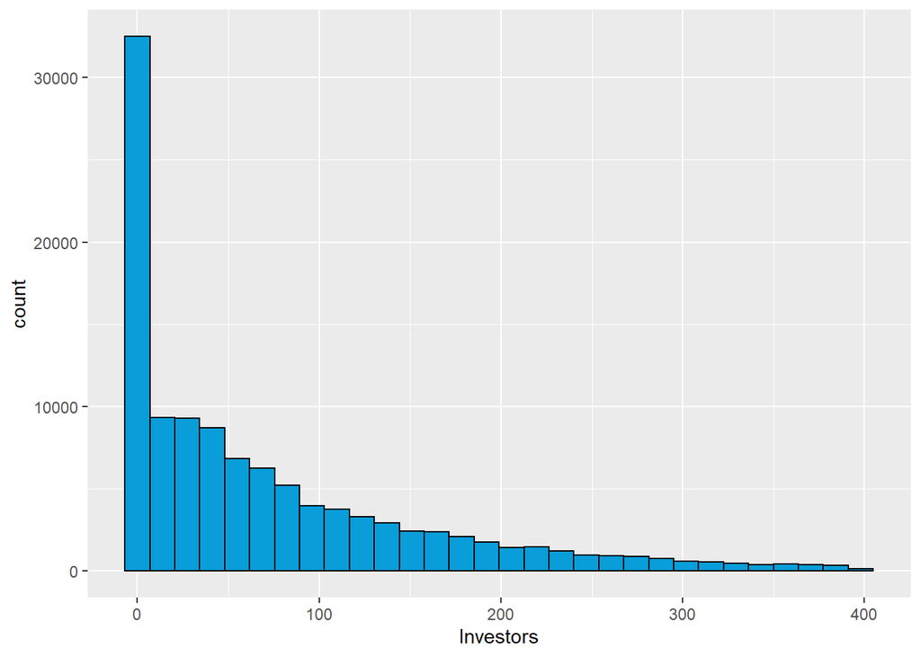

Figure 1. Histogram of the Investor variable.

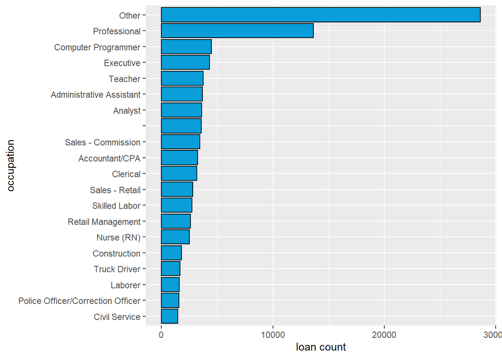

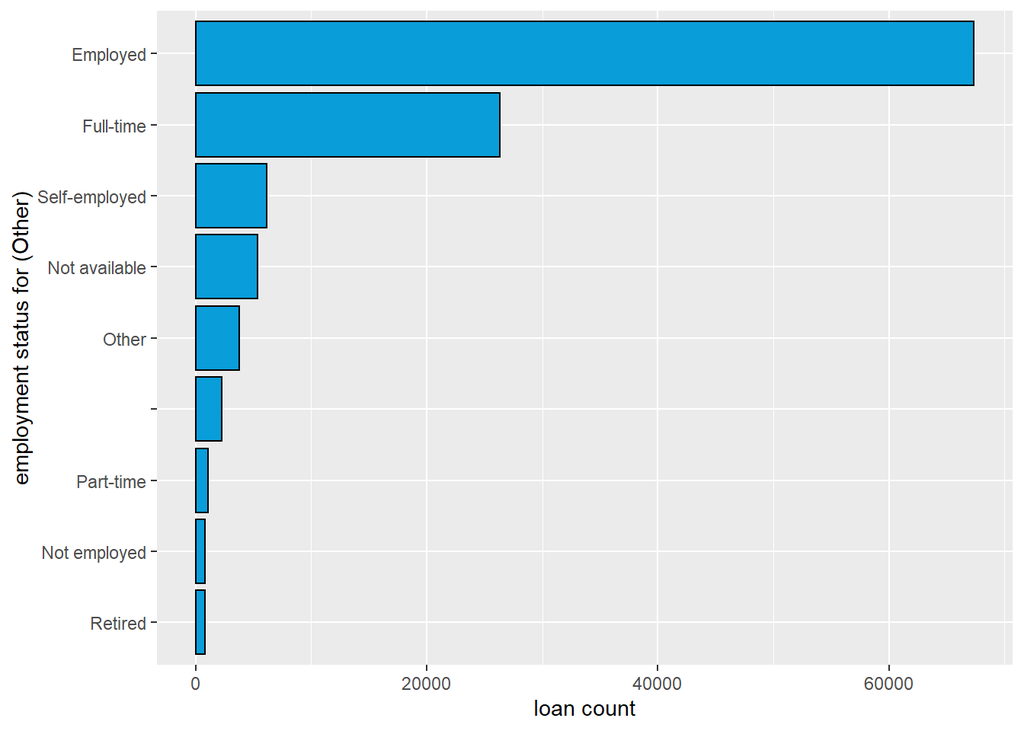

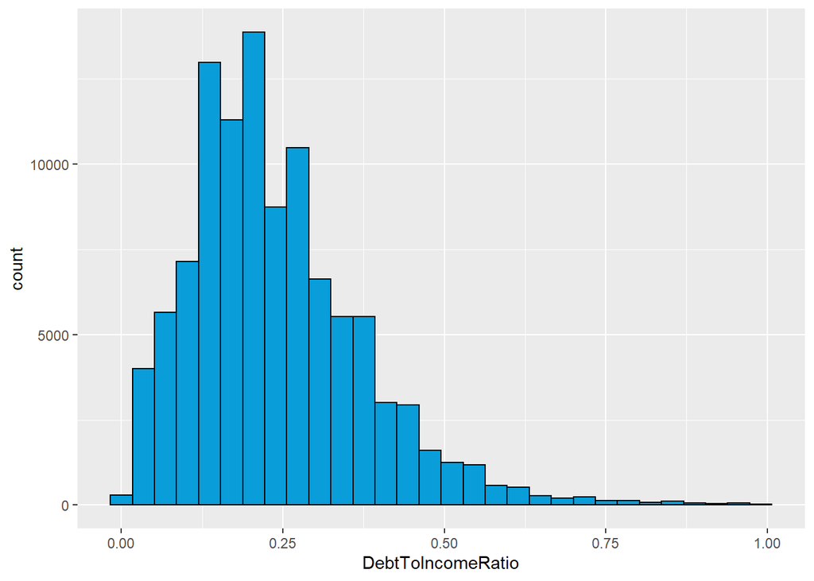

Figure 4. Loan count by Debt to Income Ration

This graph shows that Prosper has a preference towards borrowers with a Debt to Income ratio between 0.1 and 0.3.

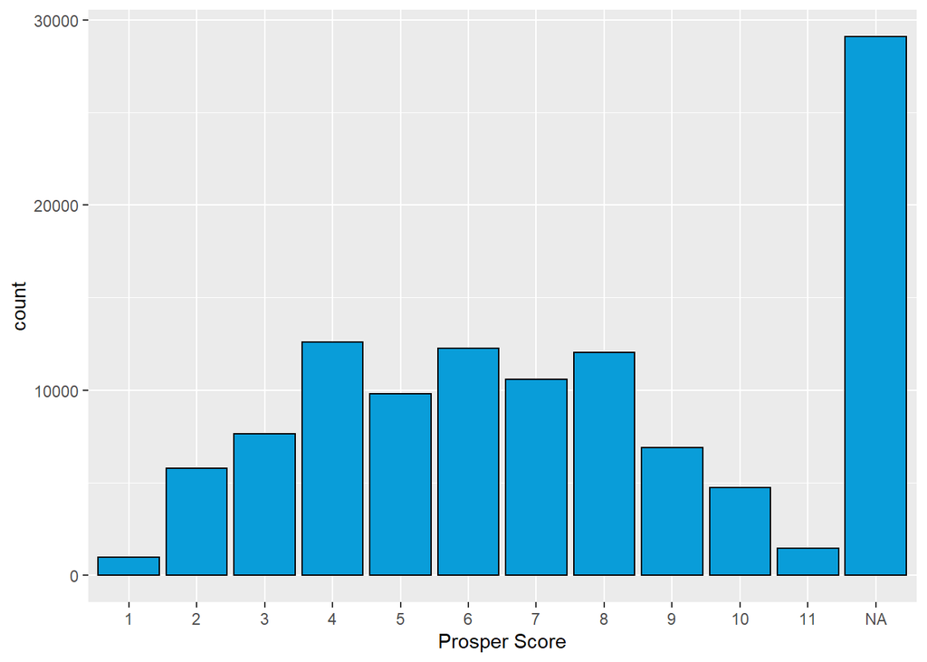

Figure 5. Loan count by Prosper score.

Prosper score is the result of risk formula applied to loans starting in 2009. Loans originating prior to 2009 show as “NA”.

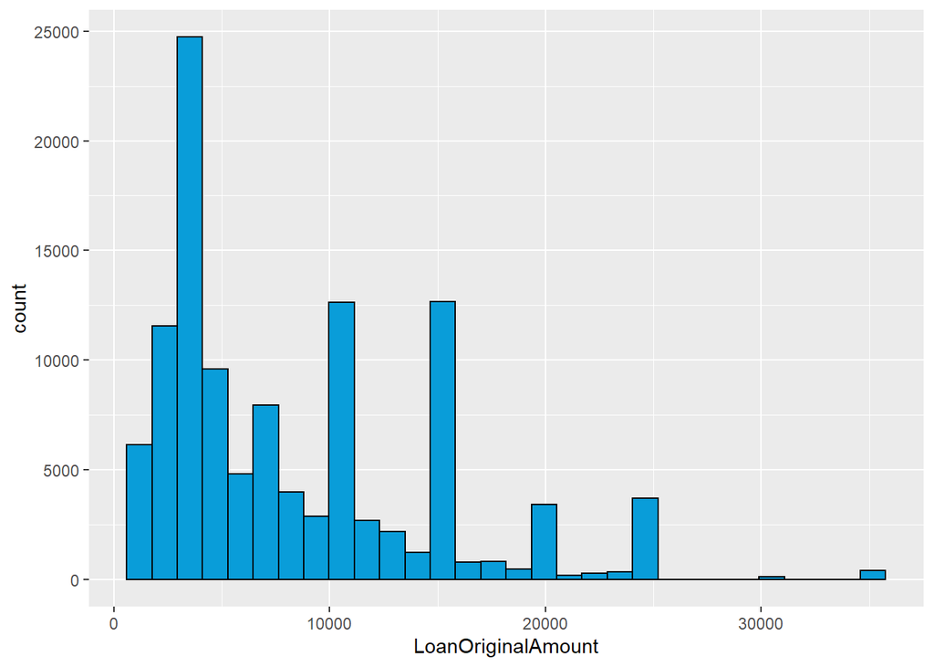

Figure 6. Loan count by Amount in Dollars.

Few loans are above $25,000.

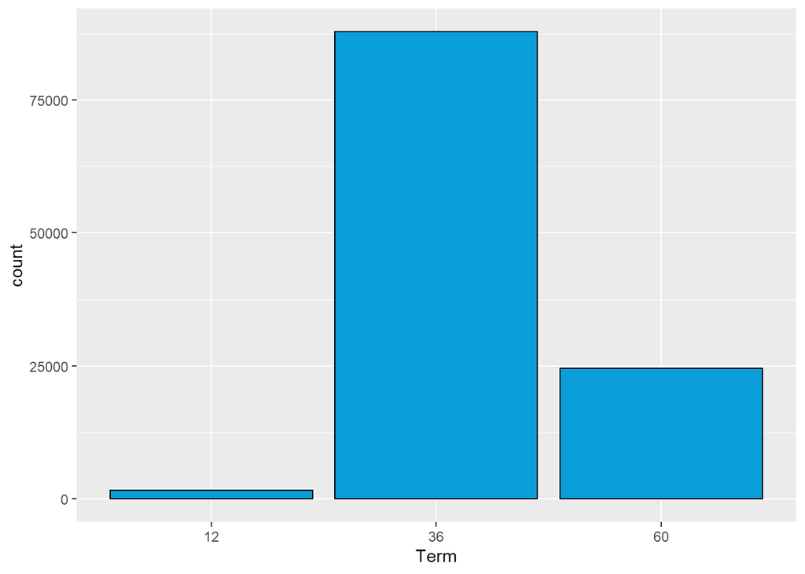

Figure 7. Loan count by Term (length of loan)

36 months is the most popular term.

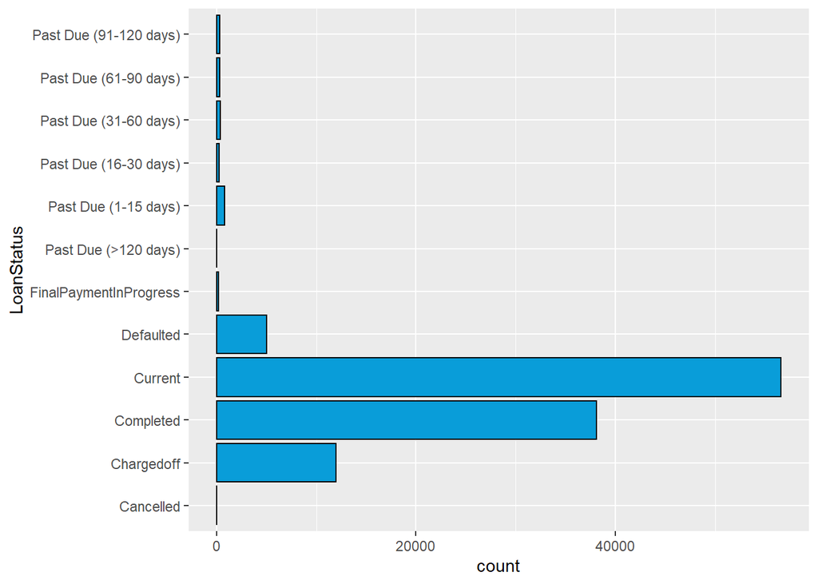

Figure 8. Loan count by Status.

Current and Complete are the most popular categories.

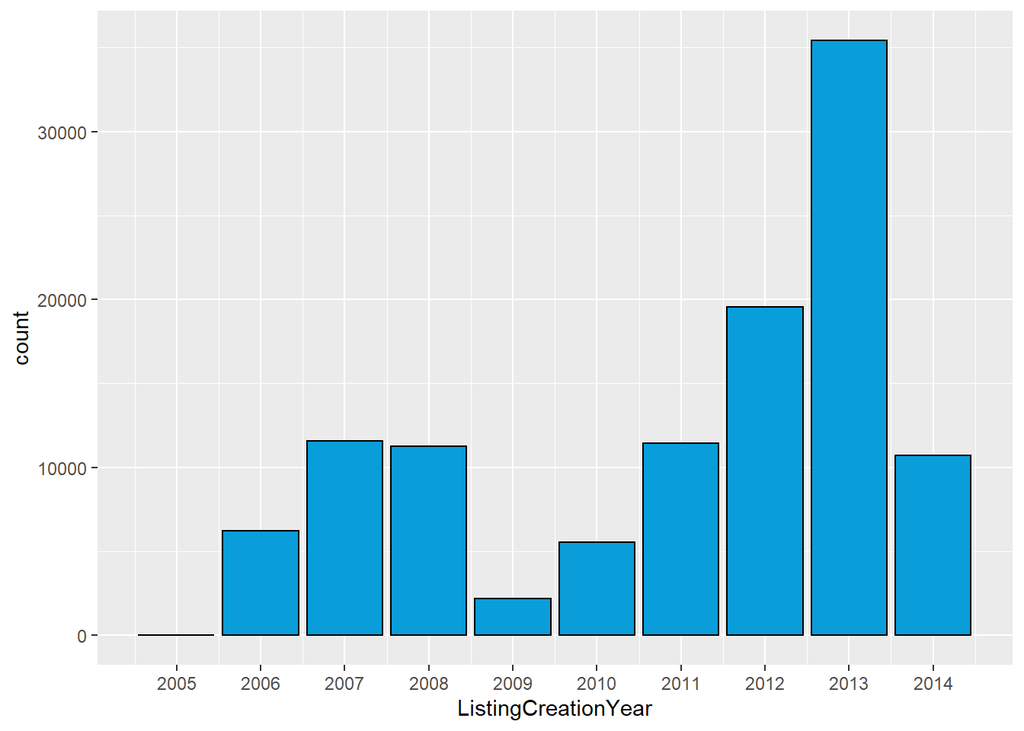

Figure 9. Loans issued by year.

The dataset begins in November 2005, hence the small number there.  
In 2009 changes in banking regulations due to the recession clearly had an affect.  
Prosper has grown considerably since. The data set ends in March 2014.

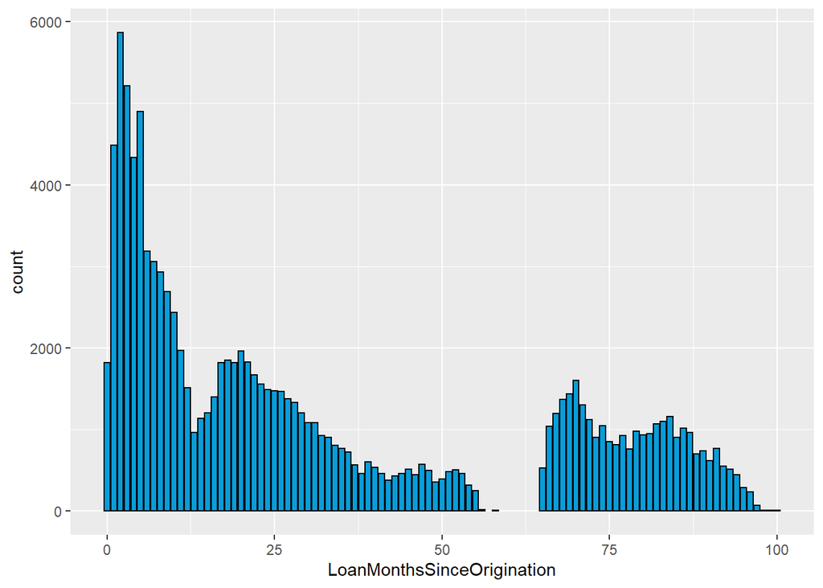

Figure 10. Number of loans by months since origination.

This is a strange variable because the months keep counting up after the loan is complete.

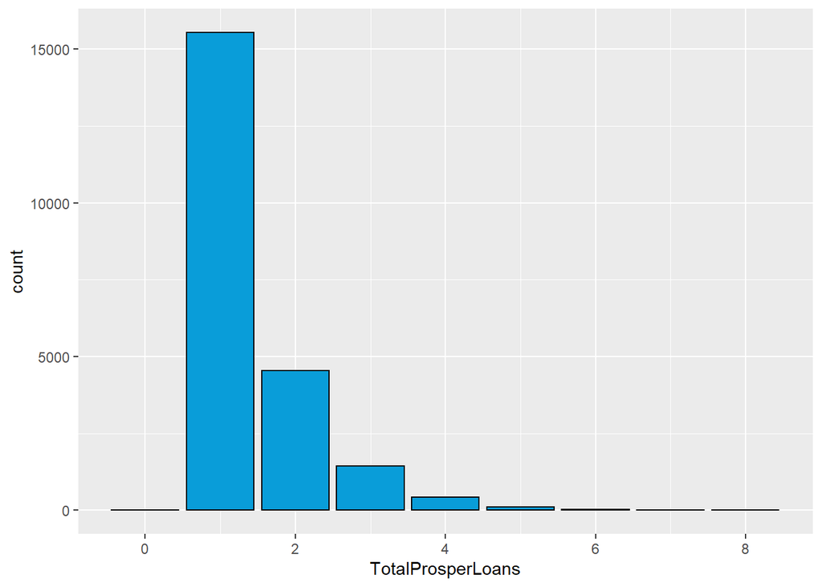

Figure 11. Number of loans by ‘total prosper loans’

The TotalProsperLoans variable is the number of Prosper loans the borrower previously had. My assumption is that preference is given to repeat customers.  
The majority of loans are first time borrowers.

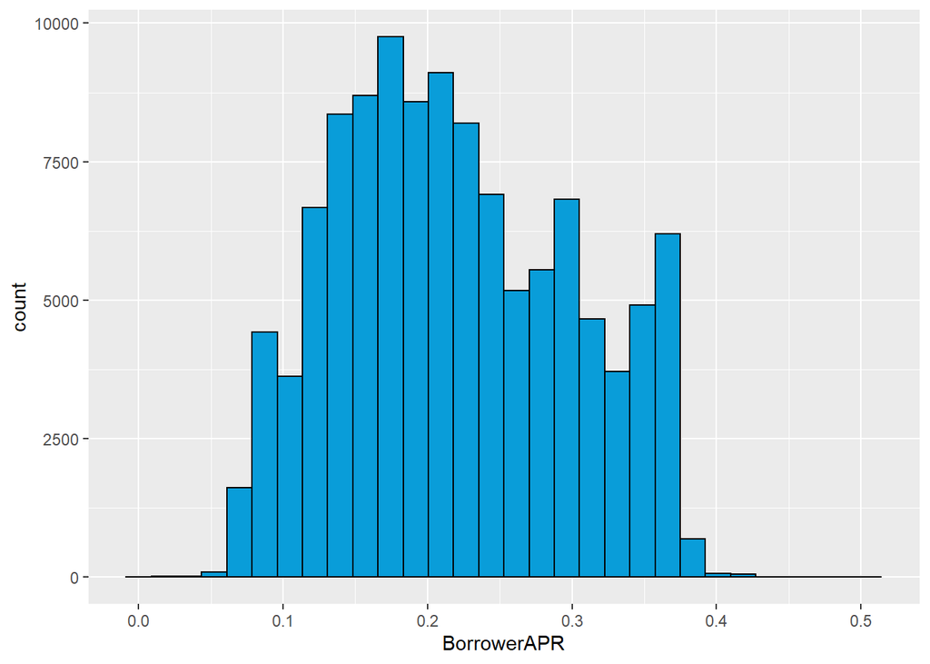

Figure 12. Number of loans by APR

Generally, a higher APR is given to loans with a higher risk and can also leads to a higher return.

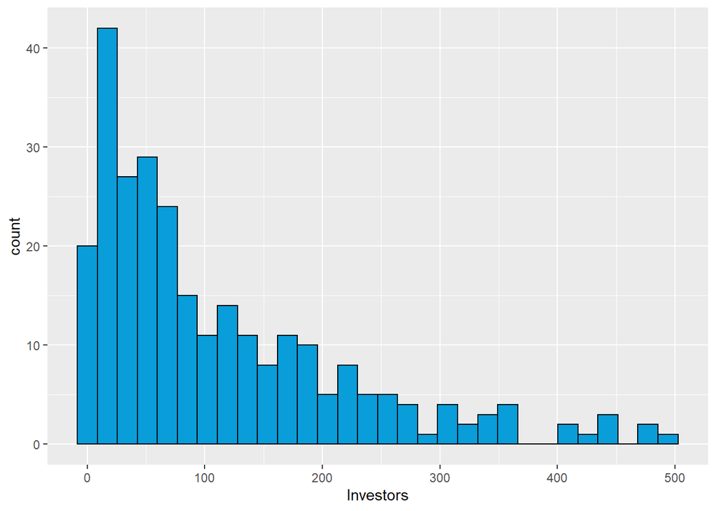

Figure 13. Number of investors where debt to income ratio is 10.01

I found it interesting that anyone would invest in a loan with such a high debt to income ratio.

# Univariate Analysis

### What is the structure of your dataset?

The dataset contains 80 variables and nearly 114,000 observations.  
The variables describe the terms of the loan, the repayment status, and the financial health of the borrower.

### What is/are the main feature(s) of interest in your dataset?

I’m interested in information about the borrower or the loan which influences investors to choose a loan.

The data spans the 2008 recession. Comparing loans before and after may show a shift in investor’s behavior or even a change lending regulations. Prosper Score was added in 2009 as a result of the recession and new regulations. Does this impact the number of investors?

### Did you create any new variables from existing variables in the dataset?

ListingCreationYear: Contains year parsed from ListingCreationDate months_active: Number of months since loan was created, but capped at the term of the loan.

# Bivariate Plots Section

What attracts investors to loans? Are they choosing wisely? Loan Status vs Investor count could show us if they are choosing wisely.  
Do loans in default have a high number of investors?

Debt to income ratio (DTI) looks interesting. The population of total loans are grouped around a seemingly low DTI with a few at the high end. In the bivariate plots section, I want to compare investors to DTI and see if the number of investors has a similar graph as the total number of loans or if investors are disproportionately flocking toward borrowers with a higher risk.

I’m also interested in investors per year because the data spans a period both before and after the 2008 recession. Were investors careless before 2008 and more conservative after?

Does occupation impact the number of investors? Perhaps they aren’t choosing based on calculations, but instead feel a need to support teachers.

I’m not as interested in Prosper score as there is no data prior to 2009.

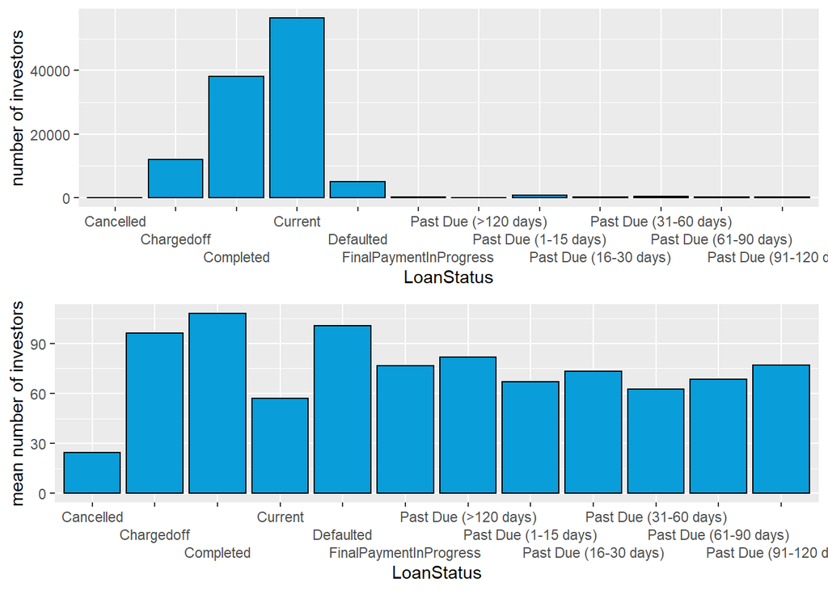

Figure 14. Investors by Loan Status

This graph shows the total number of investors by loan status. Status of “Current” has the most number of loans so the top graph is not surprising.  
Looking at the mean investors per status, we can see loans which performed poorly can have many investors per loan.

```
##    Min. 1st Qu.  Median    Mean 3rd Qu.    Max.
##   38.64   64.74   77.96   80.64   93.66  128.79
```

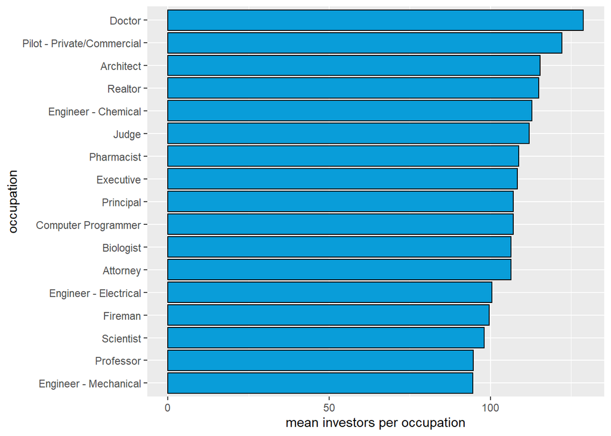

Figure 15. Mean number of investors per occupation

This graph shows the occupation of borrowers which investors are most interested in. Looking at this alone, we can’t tell if investors are choosing by occupation or if these occupations just happen to have the best credit score.

```
##    Min. 1st Qu.  Median    Mean 3rd Qu.    Max.    NA's
##   637.8   693.1   704.6   704.0   717.7   744.5       3
```

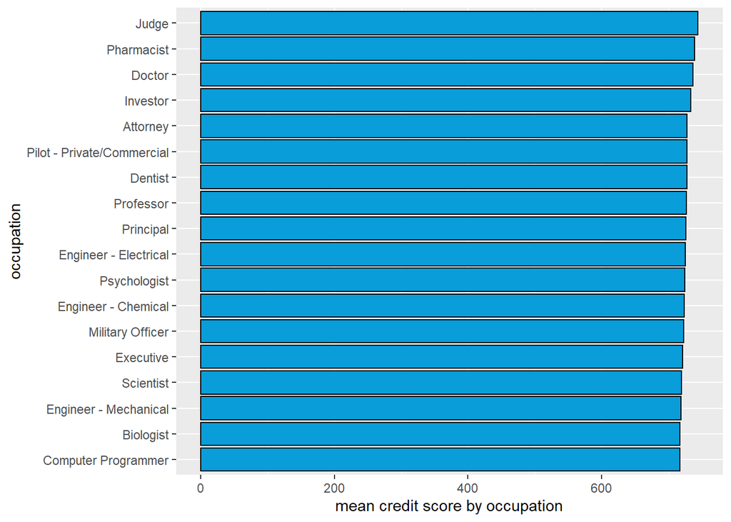

Figure 16. Mean credit score by occupation

This graph shows the 18 occupations where borrowers have the highest mean credit score. The different in credit score between each one is trivial. What is interesting is the overlap of occupations with Figure 15.  
With a few exceptions, such as Fireman and Military Officer, the occupations with the highest mean number of investors also have the highest mean credit score.

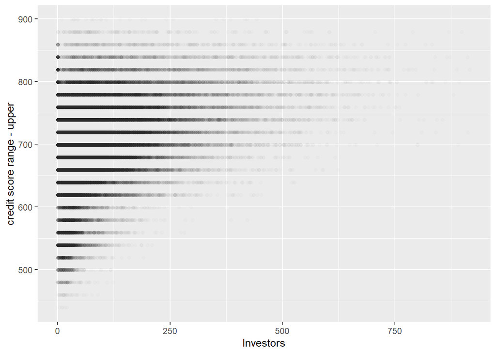

Figure 17. Number of investors by credit score where credit score is above 400 and number of investors is greater than 0 and less than 1000.

This graph shows a high concentration of loans and investors around the 750 credit score mark. Few loans have a very high number of investors and few have a credit score below 500.

I would expect this graph to be the most dense at the top of the credit score range. My guess is that few people have a perfect score and very few of those people are interested in borrowing money from Prosper.

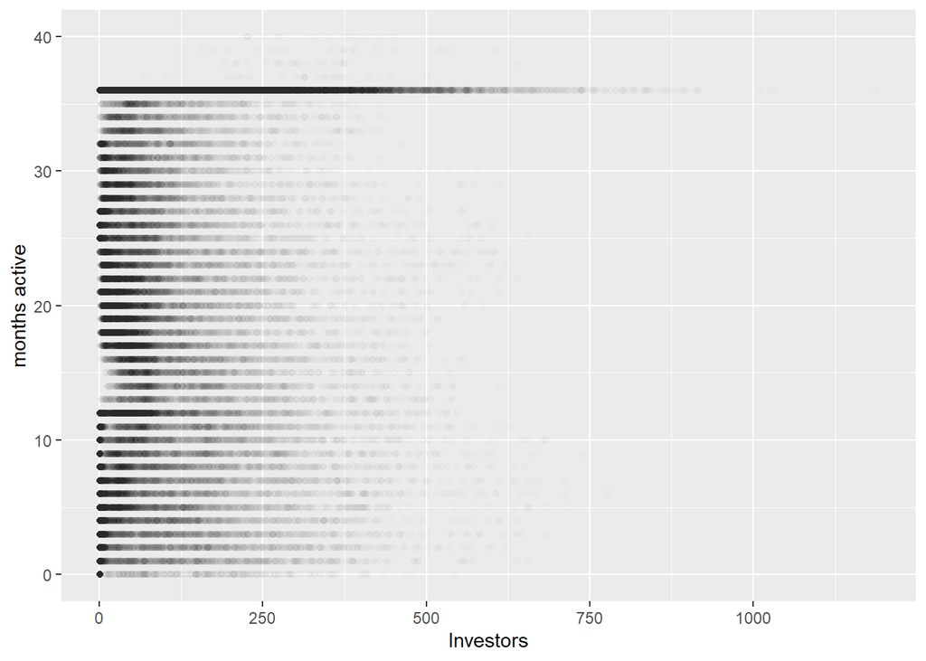

Figure 18. Number of investors by months active.

Months active is a custom variable which shows takes the number of months since loan origination and caps it at the term of the loan. I wanted to see if more investors jump on board a loan as time goes on. It appears that is not the case, however, there is a higher concentration of investors at 12 & 36 months which are popular term lengths.

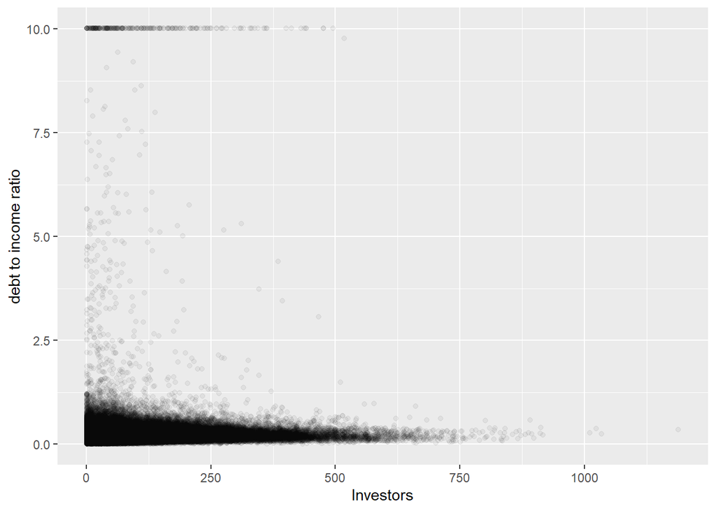

Figure 19. Number of investors by debt to income ratio.

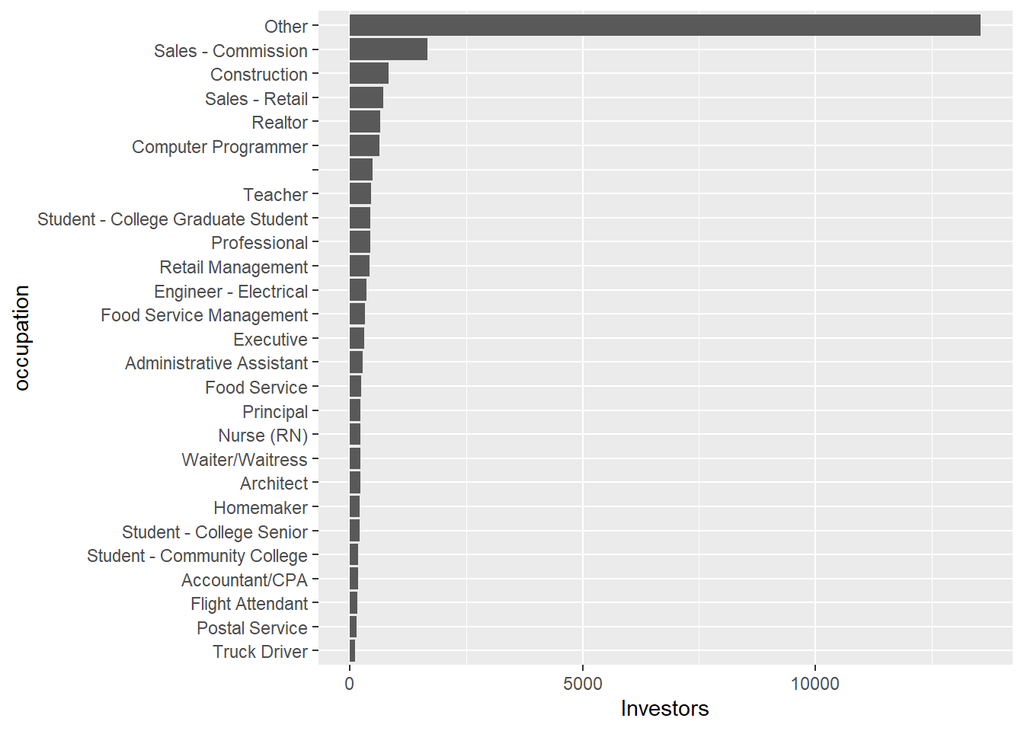

Figure 20. Number of investors by occupation where debt to income ratio = 10.01

Figure 20 expands on Figure 19 by looking at borrowers with a maximum debt to income ratio. Unfortunately, the largest category by far is “other”. This doesn’t tell us much about the borrower.

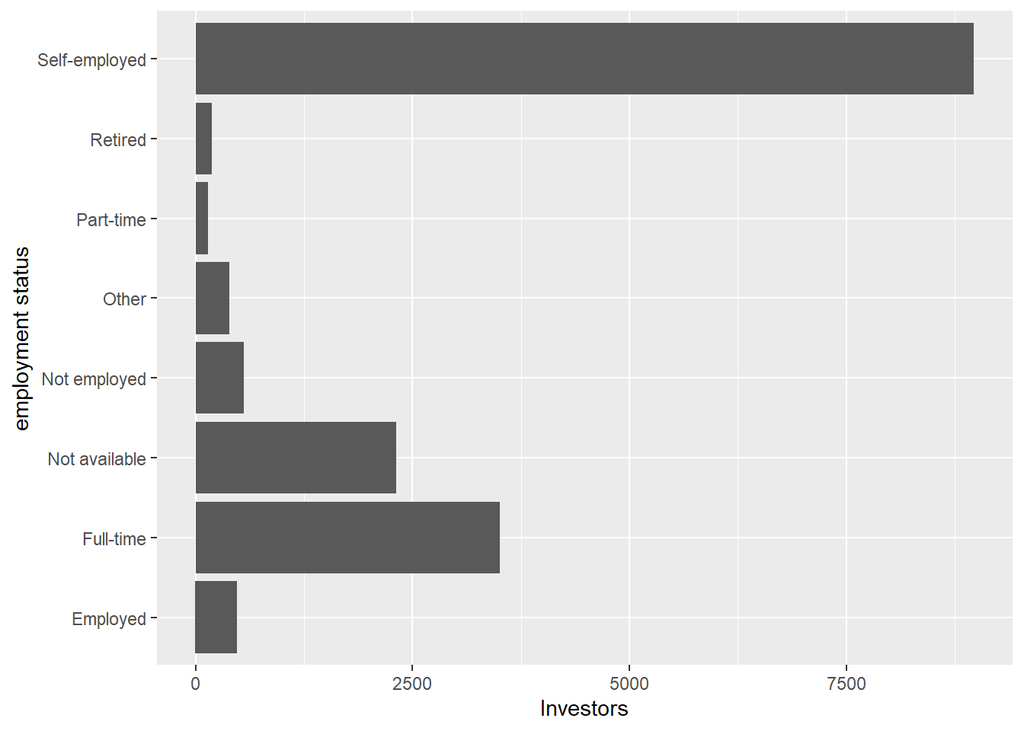

Could homeowner status also have an impact on these high risk loans?

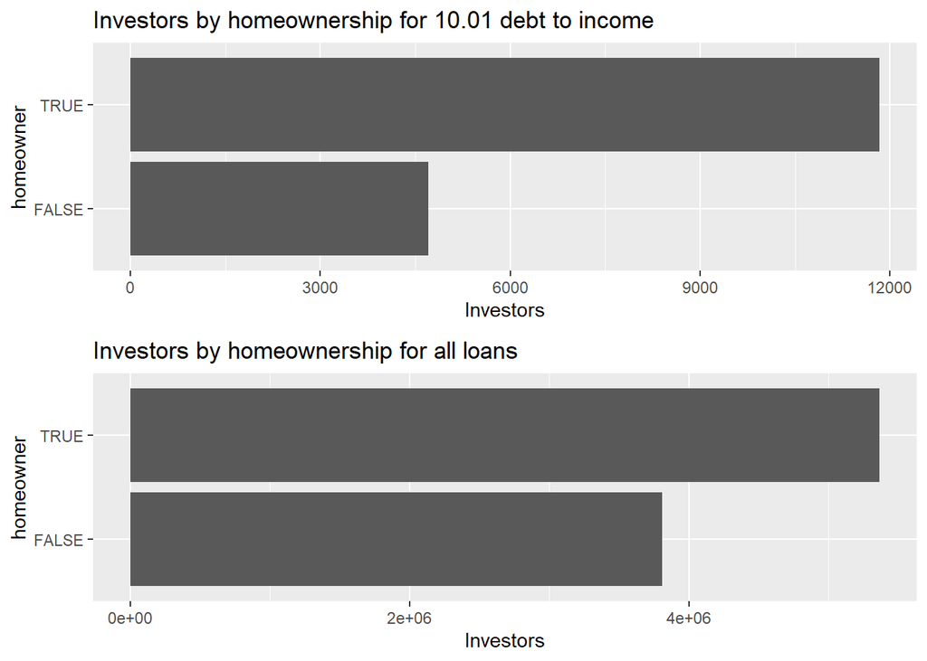

Figure 22. Investors by homeowner status for high risk loans and all loans.

Figure 22 shows that high risk loans given to homeowners have a higher proportion of investors than the entire population of loans. However in both cases that Prosper lending system favors homeowners.

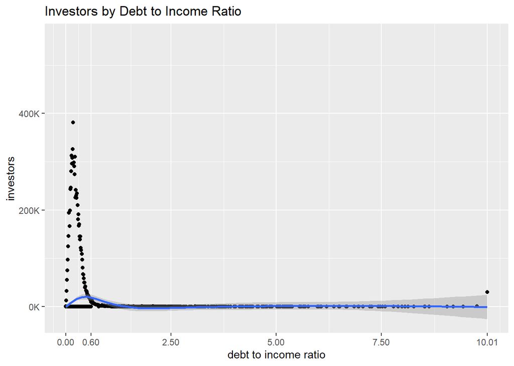

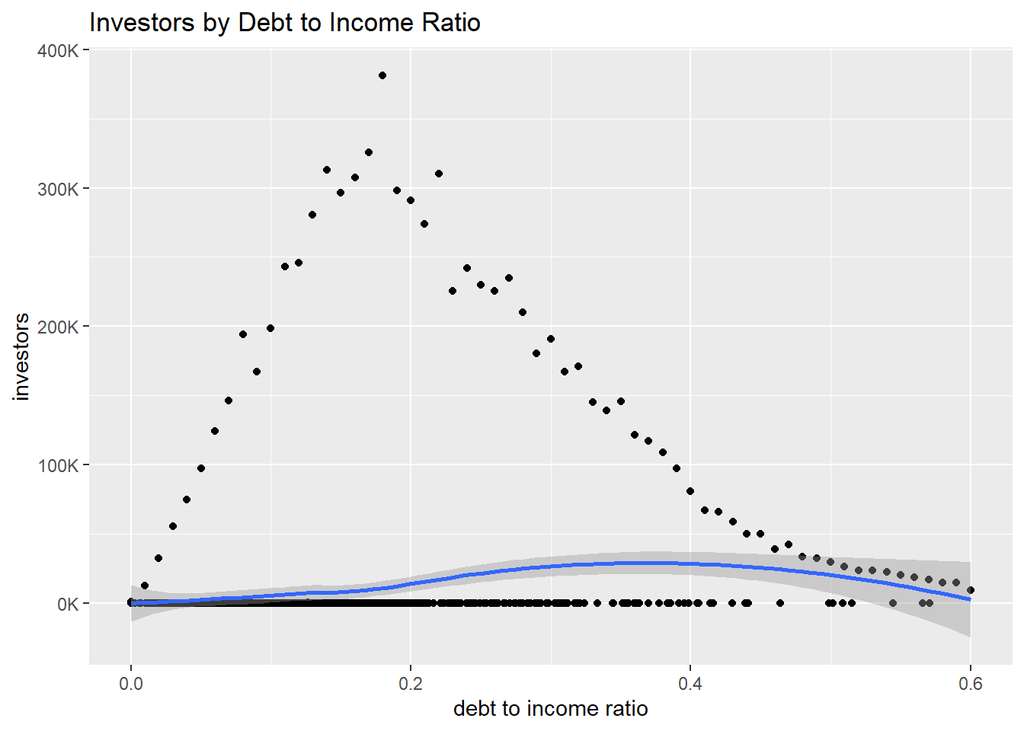

Figure 23. Debt to income ratio by number of investors Figure 24. Debt to income ratio by number of investors for 90% of loans.

Figure 23 & 24 show that Prosper and investors favor borrowers with a debt to income of 0.6 or less.

# Bivariate Analysis

### Talk about some of the relationships you observed in this part of the

investigation. How did the feature(s) of interest vary with other features in  
the dataset?

I found that investors weren’t drawn to a particular loan status.

They do seem to be drawn to particular professions, but for the most part those professions also have high credit scores. Doctor, Judge, Pharmacist, Pilot, Computer Programmer, Professors, Scientist, are examples of professions which both have a high number of investors and a high credit score. Perhaps more interesting is Fireman which shows on the list of top investors, but not on the list of top credit scores.

There does appear to be a correlation between number of investors and credit score which is not surprising. Looking at Debt to Income Ratio (DTI), Investors have a strong bias for low DTI, which also is not surprising.  
However, I was very surprised to see a spike at the extreme high end of DTI.  
According to the documentation, 10.01 is a cap for DTI and it represents more than 100% debt to income. I would assume these borrowers have no chance of paying back the loan and should not have any investors.

I zoomed into the data to look at those occupations which have extremely high DTI and found the majority to be self-employed. I believe these are business loans and the investors must be interested in taking a risk on a business idea. I can’t tell from the documentation if the investors get to see a business plan before choosing a loan or if they have to choose based solely on borrower’s statisticss.

Finally, I found a large difference between investors choosing homeowners over non-homeowners. One assumption that can be made, at least in the United States, is that homeowners tend to be a bit older and more established.  
According to nerdwallet.com, prosper loans are very popular for home improvement loans which could be another explanation.  
Perhaps these two factors compound to make such a striking difference. A another possibility is that the housing bubble pre-2009 lead to a frenzy of home equity loans and investors.

### Did you observe any interesting relationships between the other features

(not the main feature(s) of interest)?

### What was the strongest relationship you found?

Number of total investors by home ownership status.

# Multivariate Plots Section

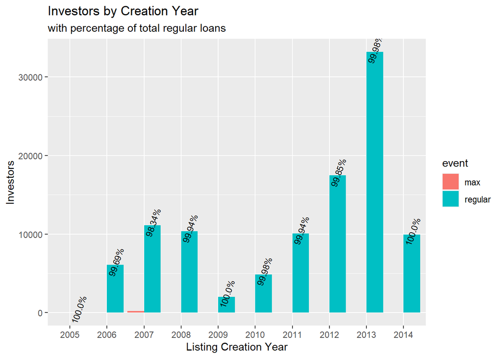

This graph shows the number of investors per year. It is split into two parts, those which are regular borrowers (below max debt to income ratio) and those which are high risk borrowers (all debt and no income). The graph also shows in text the percentage of total loans which are to regular borrowers.

The purpose is to show a feeding frenzy of investors looking for high risk investments leading up to the recession. However, this graph doesn’t fit the narrative. Loans and Investors rise quickly after the recession and the percentage of loans to borrowers with 100% debt to income is so tiny that it barely shows on this scale.

We saw in previous graphs some speculators going after high risk loans of self-employed borrowers, but that is clearly a rare occurrence.

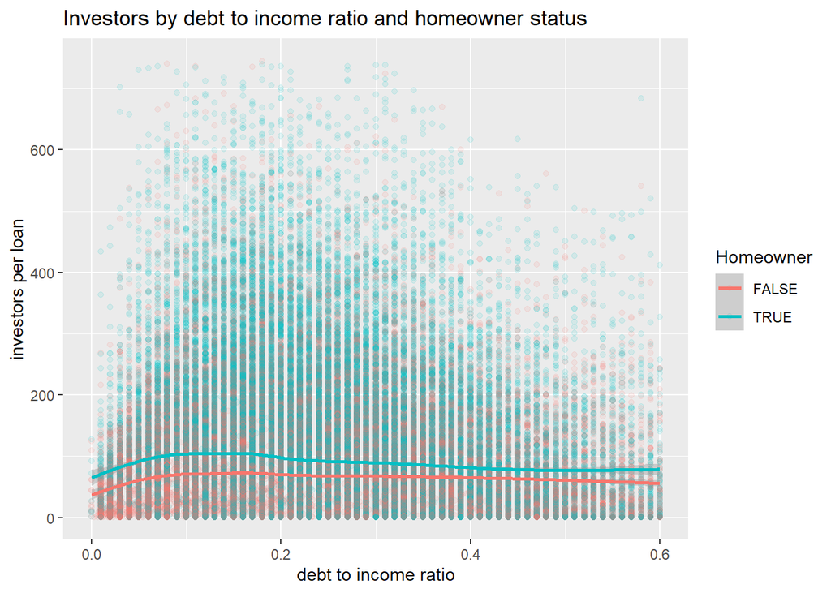

Figure 26. Investors by debt to income ration and homeowner status.

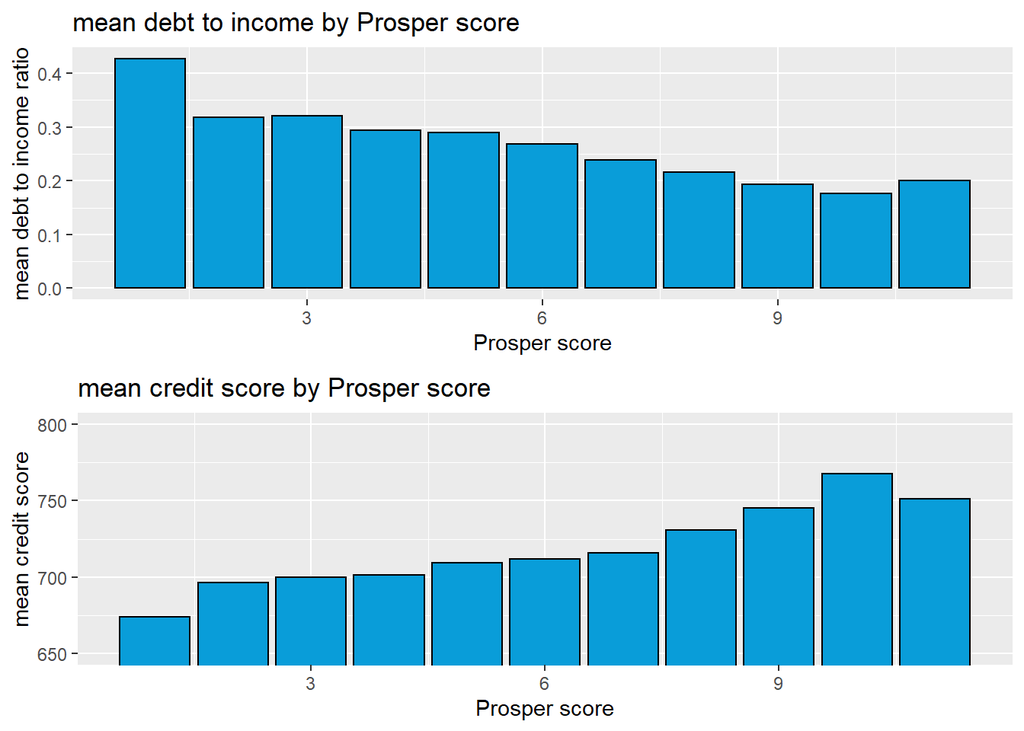

Figure 27. Debt to Income and Credit Score by Prosper score.

# Multivariate Analysis

### Talk about some of the relationships you observed in this part of the

investigation. Were there features that strengthened each other in terms of  
looking at your feature(s) of interest?

Looking at investors by debt to income ratio and investors per year investing in high risk loans, I came to the conclusion that Prosper investors are by and large looking for a safe investment, not wild speculation. There are a few exceptions, but those loans are less than 1% of the population.

### Were there any interesting or surprising interactions between features?

I was surprised by the consistency for investors to favor homeowners across the entire range of debt to income. That can’t be by chance. Another variable must be influenced by home owner status which is in turn influencing the number of loans created and the number of investors. .

### OPTIONAL: Did you create any models with your dataset? Discuss the

strengths and limitations of your model.

# Final Plots and Summary

### Plot One

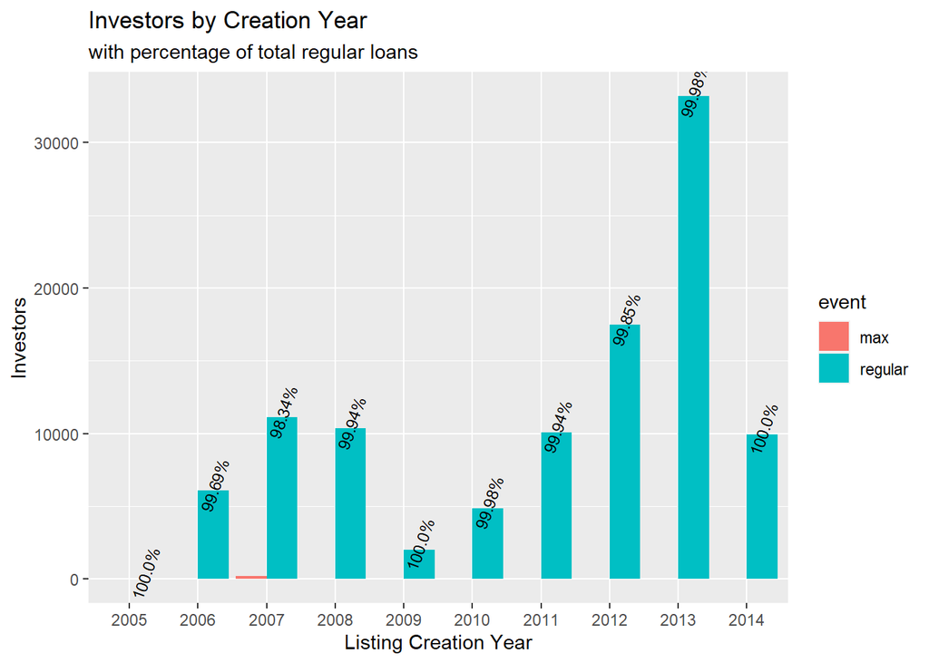

### Description One

I chose the breakdown of investors per year split into regular and maximum debt to income ratio. We showed earlier how a few high risk loans can attract a massive number of investors, however, this is clearly not the norm.  
It would be interesting to draw this same graph with data leading up to present day and see if the trend continues. It would also be interesting to have rolling datato see when investors get on board with a loan. When a loan reaches some critical mass of investors, do others simply follow the herd?

### Plot Two

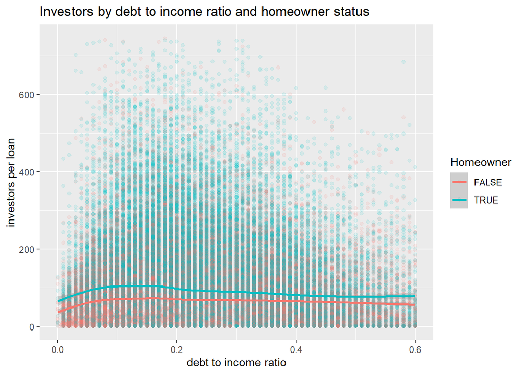

### Description Two

For plot 2, I chose to show debt to income ratio vs investors for borrowers with a DTI of 0.6 or less, separated by homeowner status.  
I chose 0.6 because 90% of all loans fall within this range. This graph shows that both prosper and investors are attracted to borrowers with a certain range of debt to income between 0.15 and 0.2. This shows investors are looking for a safe investment.

We don’t have data for individual investors. Therefore, if a single investor invests in multiple loans, he or she is counted many times. It would be interesting to know about the investor. Could we then predict which investors go after which type of loans? Could we gain insights into how to market to low and high risk investors differently to attract more?

### Plot Three

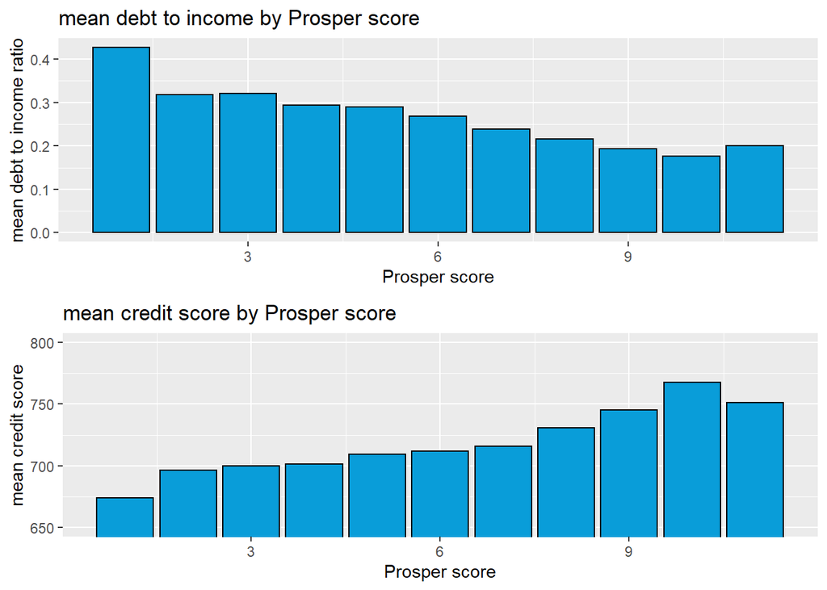

### Description Three

Finally, we see that the prosper score is related to both debt to income ratio and credit score. The higher the prosper score, the lower the risk. Prosper is using this score to advise investors. Therefore, going forward with more recent data, we should be able to predict the number of investors based on the prosper score more so than other factors such as occupation.

# Reflection

Investors are looking for a safe return on investment with the exception of a very small number of high risk loans.  
We don’t know the amount that each investor put toward each loan and we don’t know the number of distinct investors. Prosper score was added after the 2008 recession for the purpose of guiding investors and is using at least some of the same variables which investors were using individually prior to 2009.

Future work could look into whether or not investors are choosing wisely.  
The fields preceeded with “LP_” - LP_CustomerPayments - LP_CustomerPrincipalPayments - LP_InterestandFees - LP_ServiceFees - LP_CollectionFees - LP_GrossPrincipalLoss - LP_NetPrincipalLoss - LP_NonPrincipalRecoverypayments Could be analyzed to determine if investors are getting a strong return and which investors experienced opportunity cost by investing in the wrong loans. Compared the market in general, is Prosper a good choice for their portfolio?

With more information about the small number of high risk loans and the investors attracted to them, we could determine which high risk loans, if any, future investors should consider.

# References:

https://www.nerdwallet.com/reviews/loans/personal-loans/prosper-personal-loans

https://discuss.analyticsvidhya.com/t/how-to-count-number-of-distinct-values-in-a-column-of-a-data-table-in-r/1124/2

https://stackoverflow.com/questions/50935857/ggplot2-keeps-adding-5-at-end-of-year-variable-on-x-axis

https://www.roelpeters.be/scale-ggplot-y-axis-millions-or-thousands-r/